# Statistical inference with the GSS data

## Setup

### Load packages

```r
library(devtools)
```

```r
install_github("StatsWithR/statsr")
library(ggplot2)
library(dplyr)
library(statsr)
```

### Load data

Make sure your data and R Markdown files are in the same directory. When loaded your data file will be called `gss`. Delete this note when before you submit your work.

```r
load("gss.Rdata")
```

## Part 1: Data

The GSS data is collected interviewing randomly selected people in housholds in the United States. As such conclusion from this data can be considered generalizable to the US population but can not be used for reasinong on causality between variables, because no random assignment was used in collecting data.

## Part 2: Research question

I would like to analyze the relation between two variables, the frequency of newspeaper read `news` and the inflation-adjusted income `coninc`. This should adress the question ‘Does reading news and keeping updated relate with the family income?’ People often says tha keeping yourself informed helps in the game of life, I want to see this here. Moreover I would like to see how this relation has changed over a 20 years span, focusing on 1982 and 2012.

## Part 3: Exploratory data analysis

First let’s have a look ato some common statistics of the income `coninc` grouped by the news habits, on the whole dataset

```r
nnrow <- gss %>%
  filter(!is.na(coninc))%>%
  nrow()
gss %>%
  group_by(news) %>%
  filter(!is.na(coninc))%>%
  summarise(freq = n()/nnrow, avarege_income = mean(coninc), median_income = median(coninc),
            std_income = sd(coninc))
```

```
## # A tibble: 6 x 5
##                news       freq avarege_income median_income std_income
##              <fctr>      <dbl>          <dbl>         <dbl>      <dbl>
## 1          Everyday 0.29871955       49483.72         40577   36983.92
## 2  Few Times A Week 0.13499375       43123.12         34487   34699.94
## 3       Once A Week 0.08092598       37617.95         29574   31649.74
## 4 Less Than Once Wk 0.06314413       37136.33         28501   32758.46
## 5             Never 0.04707995       32158.97         20950   33790.98
## 6              <NA> 0.37513663       45307.96         36135   36341.51
```

Even if the avarages and the medians change with the variable `news` the large standard deviation suggests that this differences are not that significant. Let’s visualize this with a boxplot

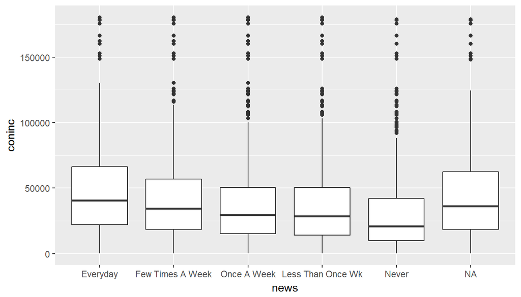

```r
gss %>%
  filter(!is.na(coninc)) %>%
  ggplot(aes(x = news, y = coninc)) +
  geom_boxplot()
```

As we were wondering, the interquartile boxes have a lot of overlap so probabli the difference won’t be that significant. Before going to test our question we look at the same picture in two particular years, 1982 and 2012.

```r
nnrow <- gss %>%
  filter(!is.na(coninc) & year == 1982)%>%
  nrow()
gss %>%
  group_by(news) %>%
  filter(!is.na(coninc) & year == 1982)%>%
  summarise(freq = n()/nnrow, avarege_income = mean(coninc), median_income = median(coninc),
            std_income = sd(coninc))
```

```
## # A tibble: 6 x 5
##                news        freq avarege_income median_income std_income
##              <fctr>       <dbl>          <dbl>         <dbl>      <dbl>
## 1          Everyday 0.523525908       40877.10         33931   29383.76
## 2  Few Times A Week 0.226920786       34760.65         29406   26775.46
## 3       Once A Week 0.114949375       27199.51         20358   21071.53
## 4 Less Than Once Wk 0.075044669       25079.85         20358   18777.44
## 5             Never 0.057772484       24828.81         16287   24193.41
## 6              <NA> 0.001786778       22469.67         16287   18222.40
```

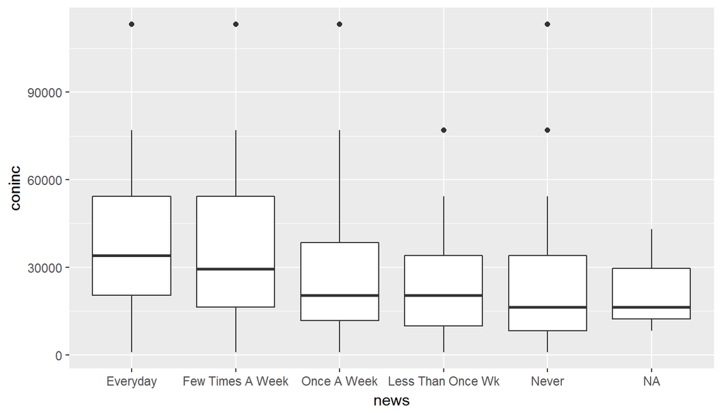

```r
gss %>%
  filter(!is.na(coninc) & year == 1982) %>%
  ggplot(aes(x = news, y = coninc)) +
  geom_boxplot()
```

Differences are more marked in 1982 then in the whole dataset. Moreover the distribution of the pupolation with respect to the variable news is remarkably more concentreted on Everyday and Few Times a Week.

```r
nnrow <- gss %>%
  filter(!is.na(coninc) & year == 2012)%>%
  nrow()
gss %>%
  group_by(news) %>%
  filter(!is.na(coninc) & year == 2012)%>%
  summarise(freq = n()/nnrow, avarege_income = mean(coninc), median_income = median(coninc),
            std_income = sd(coninc))
```

```
## # A tibble: 6 x 5
##                news       freq avarege_income median_income std_income
##              <fctr>      <dbl>          <dbl>         <dbl>      <dbl>
## 1          Everyday 0.18430034       59699.21         42130   52518.46
## 2  Few Times A Week 0.11717861       45908.67         34470   42323.74
## 3       Once A Week 0.09897611       42990.16         28725   43180.31
## 4 Less Than Once Wk 0.11092150       40321.17         28725   39219.16
## 5             Never 0.15130830       45500.33         28725   48608.41
## 6              <NA> 0.33731513       48591.76         34470   46335.47
```

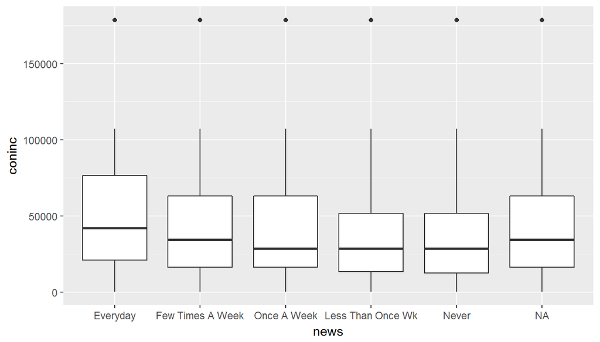

```r
gss %>%
  filter(!is.na(coninc) & year == 2012) %>%
  ggplot(aes(x = news, y = coninc)) +
  geom_boxplot()
```

The year 2012 represent better the situation on the whole dataset.

## Part 4: Inference

We will do different inference tests here, using the `inference` function from the `statsr` library.

### ANOVA news vs income

Check the difference in avarage of a continuous variable between classes of a categorical with an ANOVA requires the contiuous variable to be nearly normal. `coninc`is right skewed, so first we try to normalize it with a log1p transform.

```r
gss <- gss %>%
  mutate(coninc_ln1p = log1p(coninc))
gss %>%
  group_by(news) %>%
  filter(!is.na(news) & !is.na(coninc_ln1p))%>%
  summarise(count = n(), avarege_income = mean(coninc_ln1p),
            median_income = median(coninc_ln1p),
            std_income = sd(coninc_ln1p),
            rel_sigma = std_income/avarege_income )
```

```
## # A tibble: 5 x 6
##                news count avarege_income median_income std_income
##              <fctr> <int>          <dbl>         <dbl>      <dbl>
## 1          Everyday 15304      10.492125     10.610981  0.8911045
## 2  Few Times A Week  6916      10.312669     10.448367  0.9632921
## 3       Once A Week  4146      10.152205     10.294685  0.9934908
## 4 Less Than Once Wk  3235      10.106092     10.257730  1.0383812
## 5             Never  2412       9.866897      9.949942  1.1151048
## # ... with 1 more variables: rel_sigma <dbl>
```

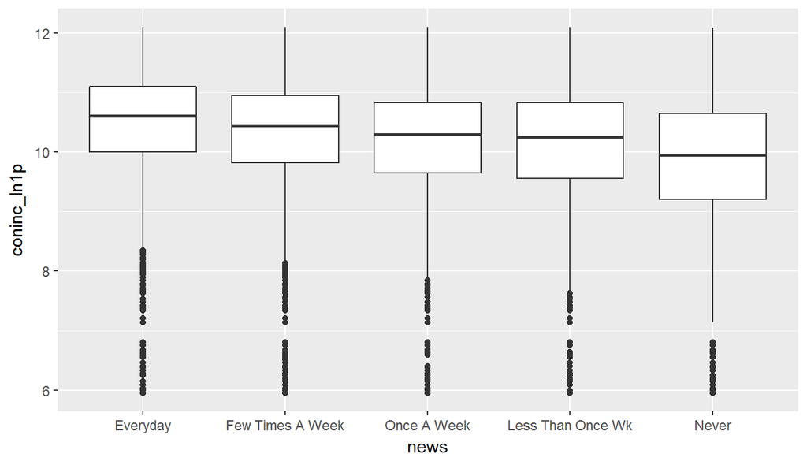

```r
gss %>%
  filter(!is.na(news) & !is.na(coninc_ln1p)) %>%
  ggplot(aes(x = news, y = coninc_ln1p)) +
  geom_boxplot()
```

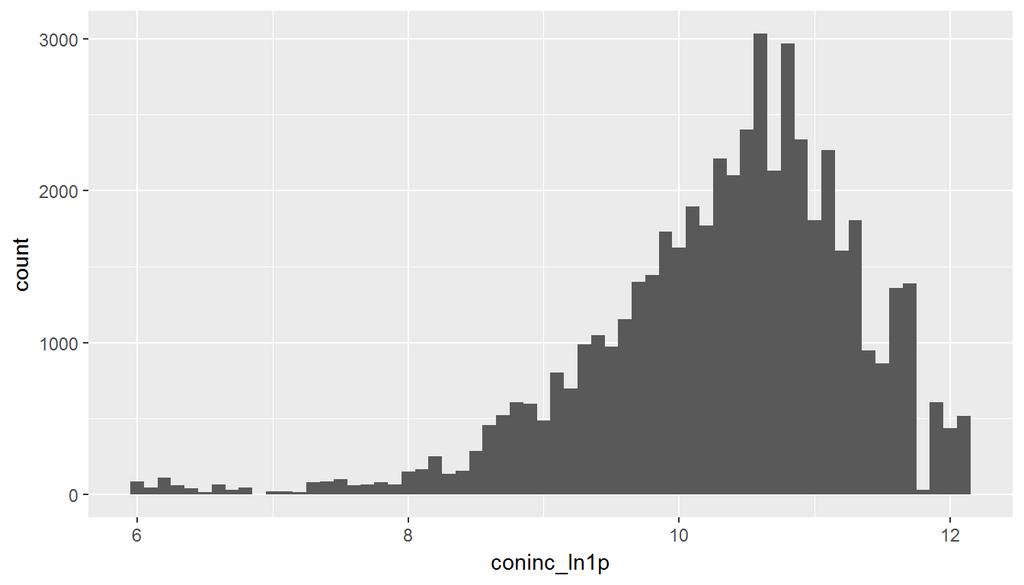

```r
gss %>%
  filter(!is.na(coninc_ln1p)) %>%
  ggplot(aes(x = coninc_ln1p)) +
  geom_histogram(binwidth = 0.1)
```

even if not perfectly normal (now it is slightly left skewed), medians and means are much more similar and we will use this for the ANOVA, taking this as sufficiently normal. Next the standard deviation between classes varies from 0.89 to 1.11, and these are between 8.5% to 11 % of the respective averages. So we consider the variances to be about equal across the classes. Finally the samples are considered independent since the GSS is supposed to randomly sample , and the sample sizes are less the 10% of the population. We can now perform an ANOVA test on the whole dataset

```r
gss_income <- gss %>%
  filter(!is.na(coninc_ln1p) & !is.na(news))

inference(y = coninc_ln1p, x = news, data = gss_income, statistic = "mean", type = "ht",
          alternative = "greater", method = "theoretical")
```

```
## Response variable: numerical
## Explanatory variable: categorical (5 levels)
## n_Everyday = 15304, y_bar_Everyday = 10.4921, s_Everyday = 0.8911
## n_Few Times A Week = 6916, y_bar_Few Times A Week = 10.3127, s_Few Times A Week = 0.9633
## n_Once A Week = 4146, y_bar_Once A Week = 10.1522, s_Once A Week = 0.9935
## n_Less Than Once Wk = 3235, y_bar_Less Than Once Wk = 10.1061, s_Less Than Once Wk = 1.0384
## n_Never = 2412, y_bar_Never = 9.8669, s_Never = 1.1151
##
## ANOVA:
##              df     Sum_Sq  Mean_Sq        F  p_value
## news          4  1213.3978 303.3494 333.1545 < 0.0001
## Residuals 32008 29144.4658   0.9105
## Total     32012 30357.8636
##
## Pairwise tests - t tests with pooled SD:
##               group1            group2    p.value
## 1   Few Times A Week          Everyday  1.992e-38
## 2        Once A Week          Everyday  1.900e-91
## 3  Less Than Once Wk          Everyday  2.082e-96
## 4              Never          Everyday 7.092e-194
## 6        Once A Week  Few Times A Week  1.162e-17
## 7  Less Than Once Wk  Few Times A Week  3.141e-24
## 8              Never  Few Times A Week  2.359e-86
## 11 Less Than Once Wk       Once A Week  3.940e-02
## 12             Never       Once A Week  1.964e-31
## 16             Never Less Than Once Wk  1.259e-20
```

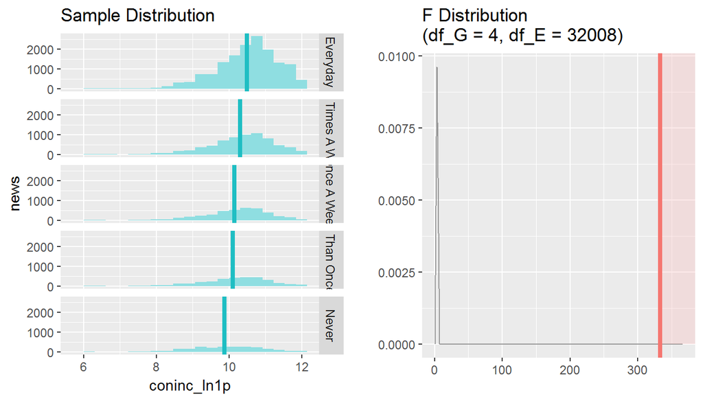

The ANOVA test results in small p-value, so the null-hypothesis “The avarage income is equal for all the classes of reading a newspaper” is refused in favor of accepting the alternative hypothesis. Moreover the `inference`function provides us with the p-values of the pairwise t-tests. having (5-1)*4/2 = 10 pairs, and starting from a significance of 0.05, all the pairs with p-values less then 5e-3 are to be considered significantly different in avarage of income. So evry pair except “Less then Once a Week”—“Once a Week” We now repeat the inference focusing on the years 2012 and 1982 separately.

```r
gss82 <- gss_income %>%
  filter(year == 1982)

inference(y = coninc_ln1p, x = news, data = gss82, statistic = "mean", type = "ht",
          alternative = "greater", method = "theoretical")
```

```
## Response variable: numerical
## Explanatory variable: categorical (5 levels)
## n_Everyday = 879, y_bar_Everyday = 10.297, s_Everyday = 0.9118
## n_Few Times A Week = 381, y_bar_Few Times A Week = 10.1041, s_Few Times A Week = 0.9605
## n_Once A Week = 193, y_bar_Once A Week = 9.8818, s_Once A Week = 0.8776
## n_Less Than Once Wk = 126, y_bar_Less Than Once Wk = 9.7619, s_Less Than Once Wk = 1.0006
## n_Never = 97, y_bar_Never = 9.6732, s_Never = 1.0314
##
## ANOVA:
##             df    Sum_Sq Mean_Sq       F  p_value
## news         4    73.961 18.4903 21.2255 < 0.0001
## Residuals 1671 1455.6616  0.8711
## Total     1675 1529.6226
##
## Pairwise tests - t tests with pooled SD:
##               group1            group2   p.value
## 1   Few Times A Week          Everyday 7.730e-04
## 2        Once A Week          Everyday 2.557e-08
## 3  Less Than Once Wk          Everyday 2.169e-09
## 4              Never          Everyday 5.312e-10
## 6        Once A Week  Few Times A Week 7.079e-03
## 7  Less Than Once Wk  Few Times A Week 3.705e-04
## 8              Never  Few Times A Week 5.140e-05
## 11 Less Than Once Wk       Once A Week 2.624e-01
## 12             Never       Once A Week 7.275e-02
## 16             Never Less Than Once Wk 4.816e-01
```

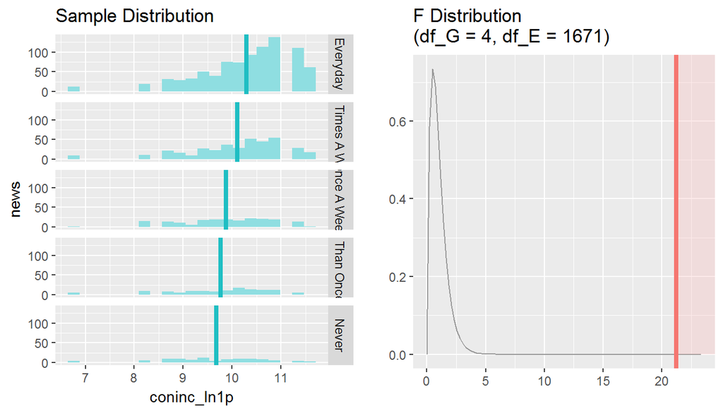

```r
gss12 <- gss_income %>%
  filter(year == 2012)

inference(y = coninc_ln1p, x = news, data = gss12, statistic = "mean", type = "ht",
          alternative = "greater", method = "theoretical")
```

```
## Response variable: numerical
## Explanatory variable: categorical (5 levels)
## n_Everyday = 324, y_bar_Everyday = 10.5831, s_Everyday = 1.0116
## n_Few Times A Week = 206, y_bar_Few Times A Week = 10.303, s_Few Times A Week = 1.0396
## n_Once A Week = 174, y_bar_Once A Week = 10.1946, s_Once A Week = 1.0882
## n_Less Than Once Wk = 195, y_bar_Less Than Once Wk = 10.1439, s_Less Than Once Wk = 1.0848
## n_Never = 266, y_bar_Never = 10.1578, s_Never = 1.2075
##
## ANOVA:
##             df    Sum_Sq Mean_Sq      F  p_value
## news         4   38.0094  9.5023 8.0359 < 0.0001
## Residuals 1160 1371.6913  1.1825
## Total     1164 1409.7007
##
## Pairwise tests - t tests with pooled SD:
##               group1            group2   p.value
## 1   Few Times A Week          Everyday 3.921e-03
## 2        Once A Week          Everyday 1.513e-04
## 3  Less Than Once Wk          Everyday 9.138e-06
## 4              Never          Everyday 2.553e-06
## 6        Once A Week  Few Times A Week 3.329e-01
## 7  Less Than Once Wk  Few Times A Week 1.432e-01
## 8              Never  Few Times A Week 1.503e-01
## 11 Less Than Once Wk       Once A Week 6.549e-01
## 12             Never       Once A Week 7.285e-01
## 16             Never Less Than Once Wk 8.923e-01
```

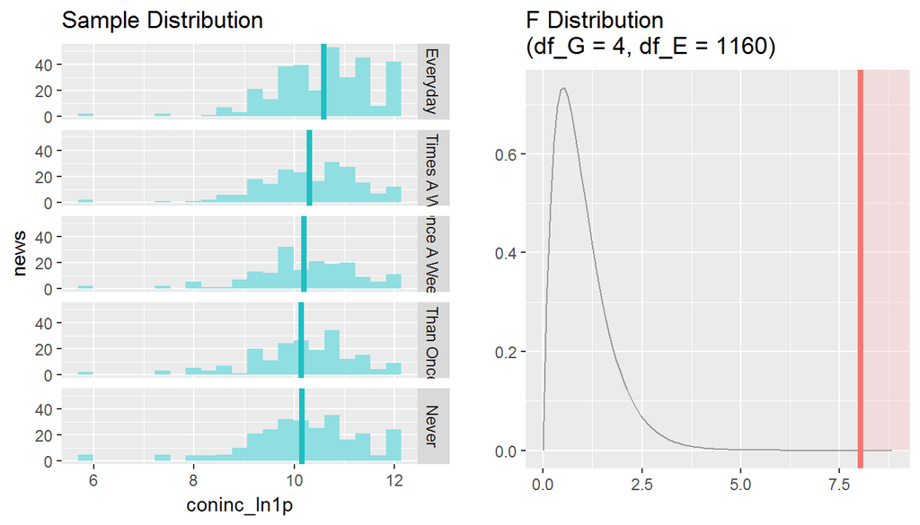

Even if both the tests for 1982 and 2012 have p-value lower then the significance level, the F-score is way more small (333 in general, 21 in 1982 and 8 in 2012). In particular in 2012 only 4 pairs pass the pairwise t-test with 0.05 significance, see the table above.